# Probability and statistics tools and demonstrations

By [Max Kapur](https://www.maxkapur.com/). Updated Jan. 27, 2020.

These notes are written at the level of the concepts they address. That is, I try not to reference concepts from later sections when solving problems from early in the text.

```python
import numpy as np
import pandas as pd
import sympy
import matplotlib.pyplot as plt
import matplotlib.cm as cm
from mpl_toolkits.mplot3d import Axes3D
from scipy.special import binom
from scipy.stats import chi2, gamma, norm, t, rankdata
from scipy.optimize import minimize
from math import factorial
```

## Independent and dependent probability

Reference: Robert V. Hogg et al., *Probability and Statistical Inference* 9e, section 1.4.

A homework problem from this section reads,

> An urn contains 10 red and 10 white balls. The balls are drawn from the urn at random, one at a time. Find the probabilities that the fourth white ball is the fourth, fifth, sixth, or seventh ball drawn if the sampling is done
> 1. With replacement.
> 2. Without replacement.
> 3. In the World Series, the American League (red) and National League (white) teams play until one team wins four games. Do you think that the urn model presented in this exercise could be used to describe the probabilities of a 4-, 5-, 6-, or 7-game series? (Note that either “red” or “white” could win.) If your answer is yes, would you choose sampling with or without replacement in your model? (For your information, the numbers of 4-, 5-, 6-, and 7-game series, up to and including 2012, were 21, 24, 23, 36. This ignores games that ended in a tie, which occurred in 1907, 1912, and 1922. Also, it does not include the 1903 and 1919–1921 series, in which the winner had to take five out of nine games. The World Series was canceled in 1994.)

I will use Python to demonstrate how list comprehensions can cut down on the busy work otherwise required by this problem. (Take a look at the ratio of text to code in this section.)

First, let’s think about what it means for the fourth white ball to occur on the *n*th trial.

There is only one way for the fourth white ball to occur on the fourth trial: all of the preceding balls must have also been white. For a reason that will be clear in a moment, we can express this one possible arrangement as the binomial coefficient $1 = \binom{3}{3}$.

For the fourth white ball to occur on the fifth trial, there must have been exactly three white balls on trials one through four (any more, and the experiment has terminated; any fewer, and we’ll need to run more trials). There are $\binom{4}{3} = 4$ ways for that to happen:

$$\text{white, white, white, red}\\ \text{white, white, red, white} \\\text{white, red, white, white} \\\text{red, white, white, white}$$

Likewise, if we draw the fourth white ball on trial six, there are $\binom{5}{3}$ ways for there to have been exactly three white balls drawn in the preceding five trials, and so on.

The number of “ways” for the fourth white ball to occur on the *n*th trial is then $\binom{n-1}{3}$. Let’s store those values for $n = \{4,5,6,7\}$ in the variable `ways`. We will need these coefficients to answer both parts of the question.

```python
ways = np.array([binom(n-1,3) for n in range(4,8)])
ways
```

```
array([ 1.,  4., 10., 20.])
```

#### Part A

For the fourth white ball to occur on a certain trial, we need to stick exactly to the sequences enumerated above, then complete each sequence by drawing a white ball on the *n*th trial itself. In part A, we are sampling with replacement, so the probability of selecting a given ball on a given trial is always $10/20 = 1/2$. That means that each sequence of length *n* occurs with probability $\mathrm{P}(S_n) = (1/2)^n$. Let’s store these probabilities in another vector, `psn`.

Note that $S_n$ denotes the probability of *a given particular* sequence of length *n* occurring, not the (higher) probability of “any sequence containing four white outcomes, with the white outcome coming up last.”

```python
psn = np.array([0.5**n for n in range(4,8)])
psn
```

```
array([0.0625   , 0.03125  , 0.015625 , 0.0078125])
```

Now, let $A_n$ denote the event of drawing the fourth ball on the *n*th trial, or using the language above, “any sequence containing four white outcomes, with the white outcome coming up last.” Well, we already figured out the number of length-*n* sequences that fit this description when we created the `ways` variable. Multiplying those coefficients by the corresponding terms of `psn` will give us the answer to part A.

```python
ways * psn
```

```
array([0.0625 , 0.125  , 0.15625, 0.15625])
```

This is $\frac{1}{16}, \frac{1}{8}, \frac{5}{32}, \frac{5}{32}$, the answer given in the book.

However, another way to interpret the question would be to find the probability of the fourth white ball occurring on *any one* of the four trials mentioned. This is $\mathrm{P}(A_4 \cup A_5 \cup A_6 \cup A_7 )$. Since the $A_n$ are mutually exclusive (you cannot draw the fourth white ball on trial four and then again on trial five), we know:

$$\begin{align} \mathrm{P}(A_4 \cup A_5 \cup A_6 \cup A_7 ) &= \mathrm{P}(A_4) + \mathrm{P}(A_5) + \mathrm{P}(A_6) + \mathrm{P}(A_7) \\ &= \binom{3}{3}\left(\frac{1}{2}\right)^4 + \binom{4}{3}\left(\frac{1}{2}\right)^5 + \binom{5}{3}\left(\frac{1}{2}\right)^6 + \binom{6}{3}\left(\frac{1}{2}\right)^7 \\ & = \frac{1}{2} \end{align} $$

This is just the dot product of our `ways` and `psn` variables.

```python
ways @ psn
```

```
0.5
```

Doubling this number shows the probability—100%—that four white balls *or* four red balls will occur within seven trials, proving that the World Series never needs to run beyond seven games (disregarding ties).

#### Part B

This is a little trickier. We should start by noticing that the combinations that will yield terminating sequences are exactly the same. That is, we can reuse our `ways` variable, and what we need to find now is $T_n$, the probability of a given length-*n* sequence containing four white balls and $n-4$ red balls.

In the $n=4$ case, there is only one possible such sequence: $\text{white, white, white, white}$. Since we lose one white ball from the urn each time we draw one, we get a factorialish expression:

$$ \mathrm{P}(T_4) = \frac{10}{20} \cdot \frac{9}{19} \cdot \frac{8}{18} \cdot \frac{7}{17} $$

For a longer sequence, the denominator will look similar: it will have the first *n* terms of $20!$. The numerator requires a bit of attention. $10 \cdot 9 \cdot 8 \cdot 7$ will stay there, but instead of continuing to decrease, the red balls in the sequence deplete their seperate supply of ten. So, for example,

$$\mathrm{P}(T_6) = \left( \frac{10}{20} \cdot \frac{9}{19} \cdot \frac{8}{18} \cdot \frac{7}{17} \right) \cdot \left( \frac{10}{16} \cdot \frac{9}{15} \right) $$

This corresponds to the sequence $\text{white, white, white, white, red, red}$. Technically, this sequence would have terminated at the fourth trial, but rearranging the sequence of draws only rearranges the numerator of this calculation, leaving the value of $T_6$ unchanged. Thinking hard about factorials reveals an expression for $T_n$:

$$\mathrm{P}(T_n) = \frac{(20 - n)!}{20!} \cdot \frac{10!}{6!} \cdot \frac{10!}{(14-n)!}$$

Let’s put $\mathrm{P}(T_n)$ for $n = \{4,5,6,7\}$ into the variable `ptn`. These values will replace the $(1/2)^n$ terms we saw in part A.

```python
d = factorial(10)*factorial(10) / (factorial(20) * factorial(6))
ptn = np.array([d * factorial(20-n) / factorial(14-n) for n in range(4,8)])
ptn
```

```
array([0.04334365, 0.02708978, 0.01625387, 0.00928793])
```

Just as above, we can answer part B with term-by-term product of `ways` and `ptn`.

```python
ways * ptn
```

```
array([0.04334365, 0.10835913, 0.1625387 , 0.18575851])
```

The textbook gives $\frac{14}{323}, \frac{35}{323}, \frac{105}{646}, \frac{60}{323}$, which is the same.

We might also choose to give the sum of these probabilities, or the probability that the fourth white ball occurs before the eighth trial. If we did things right, this should also be 0.5, because of the aforementioned symmetry between the white and red versions of this problem.

```python
ways @ ptn
```

```
0.5
```

#### Part C

Before answering the question as posed, let’s consider the two models we’ve created. In part A, we replaced the balls after pulling them, meaning that each trial was independent. In part B, the probability of pulling a white or red ball depends on how many balls have been taken out so far. If we’ve already removed three white balls, then the urn contains only seven white balls and ten red ones; a red one is more likely on our next pull.

The self-correcting nature of the dependent version of this problem is evident in the graph below. Since red balls become more likely when white is “in the lead,” the likelihood of it taking seven trials to get four red balls is higher. Notice how the purple bars increase steadily in height, while the green ones reach a plateau.

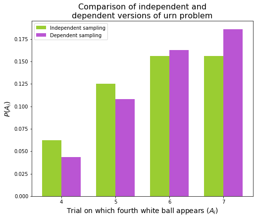

```python
x=np.arange(4,8)
width=0.36
x1 = x - width/2
x2 = x + width/2


plt.figure(figsize=(8,6.5))
plt.bar(x=x1,height=ways*psn,width=width,color='yellowgreen',label='Independent sampling')
plt.bar(x=x2,height=ways*ptn,width=width,color='mediumorchid',label='Dependent sampling')

plt.xlabel(r'Trial on which fourth white ball appears ($A_i$)',size=14)
plt.ylabel(r'$P(A_i)$',size=14)
plt.title('Comparison of independent and\ndependent versions of urn problem',size=16)
plt.xticks(x)
plt.legend()
```

My intuition says that the independent model should be a decent reflection of what happens in the World Series. While the relative skill of the teams may be different (white probably doesn’t have an exactly 50% chance of winning), it doesn’t seem to me that each team is drawing on a finite supply of wins or that their performance will deteriorate the more games they win.

On the other hand, perhaps there is an underdog phenomenon in which teams that are falling behind tend to exert themselves in hopes of a comeback victory.

On a third hand, perhaps losing teams tend to lose hope and give up after a few early losses.

If either of the previous two assertions are true, then we must discard the independent model. However, there are all sorts of dependent models possible, and the one we created above may be even worse than the independent model. In the end, neither model is suited to the real data that the textbook provides. Let’s add that to our graph, and this time we will double the probabilities obtained in the urn problem to account for the fact that four wins by *either* team ends the World Series:

```python
ws = np.array([21, 24, 23, 36])
# Divide by the sum to get the experimental probability
ws = ws / ws.sum()
```

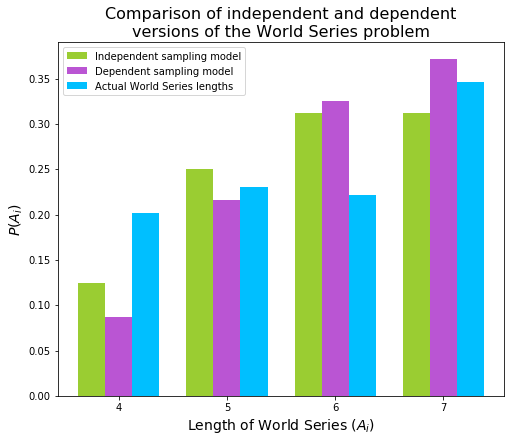

```python
x=np.arange(4,8)
width=0.25
x1 = x - width
x2 = x + width

plt.figure(figsize=(8,6.5))
# Double the models since now we allow either team to win
plt.bar(x=x1,height=2*ways*psn,width=width,color='yellowgreen',label='Independent sampling model')
plt.bar(x=x,height=2*ways*ptn,width=width,color='mediumorchid',label='Dependent sampling model')
plt.bar(x=x2,height=ws,width=width,color='deepskyblue',label='Actual World Series lengths')

plt.xlabel(r'Length of World Series ($A_i$)',size=14)
plt.ylabel(r'$P(A_i)$',size=14)
plt.title('Comparison of independent and dependent\nversions of the World Series problem',size=16)
plt.xticks(x)
plt.legend()
```

As you can see, neither model accurately predicted the true distribution of World Series lengths. It is probably reasonable to reject the hypothesis that the outcomes of the games in the World Series are completely independent of one another.

## An optimization problem involving the gamma distribution

Reference: Robert V. Hogg et al., *Probability and Statistical Inference* 9e, section 3.2.

Problem 19 reads,

> A bakery sells rolls in units of a dozen. The demand $X$ (in 1000 units) for rolls has a gamma distribution with parameters $\alpha=3$, $\theta = 0.5$, where $\theta$ is in units of days per 1000 units of rolls. It costs \$2 to make a unit that sells for \$5 on the first day when the rolls are fresh. Any leftover units are sold on the second day for \$1. How many units should be made to maximize the expected value of the profit?

We can start by setting up the demand function, which is

$$ f(x) = \frac{x^{3 - 1}e^{-x/0.5}}{\Gamma(3)(0.5)^3} = 4x^2e^{-2x}$$

Python can construct this gamma function for us using `scipy.stats.gamma.pdf`. Let’s take a look at that.

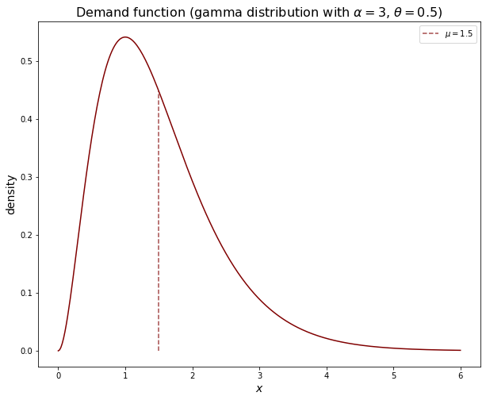

```python
def demand(x):
    return gamma.pdf(x, 3, scale=0.5)

x= np.linspace(0, 6,301)
plt.figure(figsize=(10,8))
plt.title(r'Demand function (gamma distribution with $\alpha=3$, $\theta = 0.5$)',size=16)
plt.xlabel(r'$x$', size=14)
plt.ylabel(r'density', size=14)
plt.plot(x,demand(x), color='maroon')
plt.vlines(1.5,0,demand(1.5),ls='--',color='maroon',alpha=0.7, label=r'$\mu=1.5$')
plt.legend()
```

$$C(u, x) = \begin{cases} -2u + 5u &= 3u, & u \lt x \\ -2u +5x + (u-x) &= 4x-u, & u \geq x \end{cases} $$

Since $x$ is randomly determined, what we want to maximize is the expected value of $C(u,X)$. This we must break into two integrals because the profit function is piecewise.

$$\begin{align}\mathbb{E}\left[C(u,X)\right] &= \int_{0}^{\infty}C(u,x) f(x)\,dx \\ & = \int_{0}^{u}(4x-u) 4x^2e^{-2x} \,dx + \int_{u}^{\inf}(3u) 4x^2e^{-2x} \,dx \\ \end{align}$$

Breaking up the integrals further, we discover that the expected profit function is just made up of several gamma cdfs:

$$\begin{align}\mathbb{E}\left[C(u,X)\right] &= 6\int_{0}^{u}\frac{16}{6}x^3e^{-2x} \,dx - u \int_{0}^{u} 4x^2e^{-2x} \,dx + 3u\int_{u}^{\inf} 4x^2e^{-2x} \,dx \\ &= 6 G(u) - u F(u) + 3u(1-F(u)) \\ &= 3u + 6 G(u) - 4u F(u)\end{align}$$

where $G(u)$ is the gamma cdf with $\alpha=4$, $\theta = 0.5$ and $F(u)$ is the gamma cdf with $\alpha=3$, $\theta = 0.5$.

This will make our life a lot easier, since scipy has the gamma cdf built in. To solve algebraically, we’d have to apply serial integration by parts to integrate the gamma pdfs, and even that would leave us a messy polynomial whose roots we’d have to plug into the computer.

We will define the profit function in Python as `expected_profit`.

```python
def expected_profit(u):
    return 3*u + 6*gamma.cdf(u, 4, scale=0.5) - 4*u*gamma.cdf(u, 3, scale=0.5)
```

Now that we have reduced our expected cost to a function of $u$, we need to find the maximum of this function. We know $u$ will be positive, so we will ask scipy to start at $u=0$ and move to the right. Scipy only does minimization, so we feed it the negative of our expected profit function.

```python
out = minimize(lambda u: - expected_profit(u), x0=0)
profit = -out.fun
best_u = out.x[0]
best_u, profit
```

```
(1.9602010931382516, 3.3049588923017295)
```

Looks like the optimal number of units to produce is 1960, corresponding to an expected profit of \$3305. Let’s plot this, and while we’re at it, we will correct the scale from showing the units in thousands.

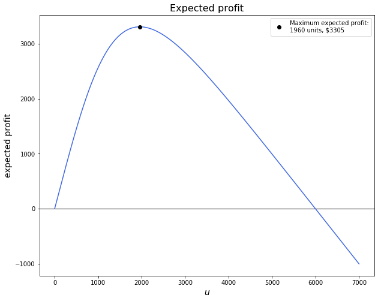

```python
u= np.linspace(0,7,351)

plt.figure(figsize=(10,8))
plt.title(r'Expected profit', size=16)
plt.axhline(color='black',lw=1)
plt.plot(1000 * u, 1000 * expected_profit(u), color='royalblue')
plt.plot(1000 * best_u, 1000 * profit,'o', label='Maximum expected profit:\n1960 units, \\$3305',color='black')
plt.xlabel(r'$u$', size=14)
plt.ylabel('expected profit', size=14)
plt.legend(loc='upper right')
```

This matches the answer given in the text.

## Derivation of the least-squares line of best fit

Reference: Robert V. Hogg et al., *Probability and Statistical Inference* 9e, section 4.2.

Online, you can find [many derivations](https://brownmath.com/stat/leastsq.htm) of the least-squares fit for when you are given $X$ and $Y$ as points of data. The textbook asks us to prove this when $X$ and $Y$ are random variables distributed according to some pmf $f(x, y)$. The proof is essentially the same, but the symbols are different. Problem 5:

> Let $X$ and $Y$ be random variables with respective means $\mu_X$ and $\mu_Y$, respective variances $\sigma_X^2$ and $\sigma_Y^2$, and correlation coefficient $\rho$. Fit the line $y = a + bx$ by the method of least squares to the probability distribution by minimizing the expectation $ K(a,b) = \mathbb{E}\left[(Y − a − bX)^2 \right]$ with respect to $a$ and $b$.

We have

$$\begin{align} K(a,b) & = \mathbb{E}\left[(Y − a − bX)^2 \right] \\ & = \mathbb{E}\left(X^2 b^2 - 2 XYb + 2X ab + Y^2 - 2Ya + a^2\right) \\ & = b^2 (\sigma_X^2 + \mu_X^2) - 2b(\sigma_{XY} + \mu_X \mu_Y) + 2ab\mu_X + \sigma_Y^2 + \mu_Y^2 - 2a\mu_Y + a^2 \end{align}$$

by expanding, distributing, then substituting $\mathbb{E}(X^2) = \sigma_X^2 + \mu_X^2$, $\mathbb{E}(Y^2) = \sigma_Y^2 + \mu_Y^2$, and $\mathbb{E}(XY) = \sigma_{XY} + \mu_X \mu_Y$.

Let’s set the first derivatives to zero and solve for $a$ and $b$.

$$\begin{align} \frac{\partial K}{\partial a} = 0 & = 2b\mu_X - 2\mu_Y + 2a \\ & \implies \bbox[4px, border: 1px solid black]{ a = \mu_Y - b\mu_X } \\ \frac{\partial K}{\partial b} = 0 & = 2b(\sigma_X^2 + \mu_X^2) - 2 (\sigma_{XY} + \mu_X \mu_Y) + 2a \mu_X \\ & = 2b(\sigma_X^2 + \mu_X^2) - 2 (\sigma_{XY} + \mu_X \mu_Y) + 2(\mu_X \mu_Y - b \mu_X^2) \\ & = 2b\sigma_x^2 - 2\sigma_{XY} \\ & \implies \bbox[4px, border: 1px solid black]{ b = \frac{\sigma_{XY}}{\sigma_X^2} = \rho \frac{\sigma_Y}{\sigma_X} } \end{align}$$

Then $$\begin{align} y & = a+bx \\ & = \mu_Y - b\mu_X + bx \\ & = \mu_Y + b(x - \mu_X) \\ & \bbox[4px, border: 1px solid black]{ = \mu_Y + \rho \frac{\sigma_Y}{\sigma_X} (x-\mu_X) } \end{align}$$

This is the form we are familiar with. Now we just need to show that this is, in fact, a minimum rather than a maximum or saddle point. Taking second derivatives:

$$\begin{align} \frac{\partial^2 K}{\partial a^2} & = 2 \\ \frac{\partial^2 K}{\partial b^2} & = 2 (\sigma_X^2 + \mu_X^2) \\ \frac{\partial^2 K}{\partial a \, \partial b} & = 2\mu_X \\ \end{align}$$

In multiple variables, the second-derivative test uses the determinant of the Hessian matrix:

$$\begin{align} \det \begin{bmatrix} \frac{\partial^2 K}{\partial a^2} & \frac{\partial^2 K}{\partial a \, \partial b} \\ \frac{\partial^2 K}{\partial b \, \partial a} & \frac{\partial^2 K}{\partial b^2} \\ \end{bmatrix} & = 2 \cdot 2 (\sigma_X^2 + \mu_X^2) - (2\mu_X)^2 \\ & = 4\sigma_X^2> 0 \\ \end{align}$$

The determinant is positive, as are $\frac{\partial^2 K}{\partial a^2}$ and $\frac{\partial^2 K}{\partial b^2}$, so we have found a minimum.

## Plotting a discrete, bivariate probability distribution

References:

- Robert V. Hogg et al., *Probability and Statistical Inference* 9e, section 4.3.
- Matplotlib, [“Demo of 3D bar charts.”](https://matplotlib.org/3.1.1/gallery/mplot3d/3d_bars.html)

Problem 11 references an interesting distribution:

> Choose a random integer $X$ from the interval $[0, 4]$. Then choose a random integer $Y$ from the interval $[0, x]$, where $x$ is the observed value of $X$. Make assumptions about the marginal pmf $f_X (x)$ and the conditional pmf $h(y | x)$ and compute $P(X + Y > 4)$.

By inspection, we see that

$$f_X (x) = 1/5, \quad x= 0, 1, 2, 3, 4$$

Then, the number of choices for $Y$ is restricted by $x$, so

$$h(y|x) = \frac{1}{x+1}, \quad 0 \leq y \leq x, \quad x \text{ is one of } \{0, 1, 2, 3, 4\}$$

Since $ h(y|x) = \frac{f(x, y)}{f_X (x)} $, we can work backwards to find the joint pmf:

$$\begin{align} f(x, y) & = f_X (x) \cdot h(y|x) \\ & = \frac{1}{5}\cdot\frac{1}{x+1} \\ & = \frac{1}{5x+5}, \quad 0 \leq x \leq 4, \quad 0 \leq y \leq x \end{align} $$

There are six points for which $x + y > 4$: $(3, 2),(3, 3),(4, 1),(4, 2),(4, 3),(4, 4)$. Since $f(x, y)$ depends only on the value of $x$, the sum of $f(x,y)$ over this space is $2/20 + 4/25 = 13/50$.

Let’s plot $f(x,y)$. First we need all the points for which $ f(x, y) \neq 0$.

```python
h = np.array([[x, y] for x in range(5) for y in range(x+1)])
h
```

```
array([[0, 0],
       [1, 0],
       [1, 1],
       [2, 0],
       [2, 1],
       [2, 2],
       [3, 0],
       [3, 1],
       [3, 2],
       [3, 3],
       [4, 0],
       [4, 1],
       [4, 2],
       [4, 3],
       [4, 4]])
```

Since the function is discrete and bound, one way to visualize it is by annotating each of the points.

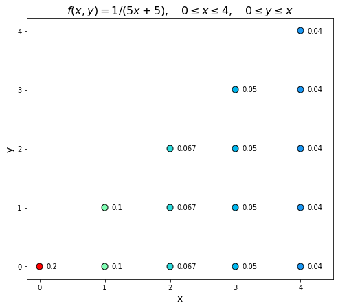

```python
# Separate the x and y coords for easy plotting
x, y = h.T
# Compute the probabilities f(x,y)
f = 1/ (5*x + 5)

colors = plt.cm.rainbow(f.flatten()/float(f.max()))

plt.figure(figsize=(8,7))
plt.title(r'$ f(x,y) = {1}/(5x+5), \quad 0 \leq x \leq 4, \quad 0 \leq y \leq x $', size=16)
plt.scatter(x,y,color=colors,s=80,edgecolor="black")
plt.xticks(np.arange(0,5))
plt.yticks(np.arange(0,5))
plt.xlim(-0.2,4.5)
plt.xlabel('x', size=14)
plt.ylabel('y', size=14)

for i, z in enumerate(f):
    plt.annotate(np.round(z, decimals=3),
                 xy=(x[i] + 0.1 ,y[i]),
                 va='center')
```

Or, we can use a 3D bar chart. Matplotlib’s 3D plotting is still pretty buggy, so we have to [tweak the viewport](https://stackoverflow.com/questions/59259099/matplotlib-3d-barplot-failing-to-draw-just-one-face/59259301#59259301) or it will fail to draw some faces.

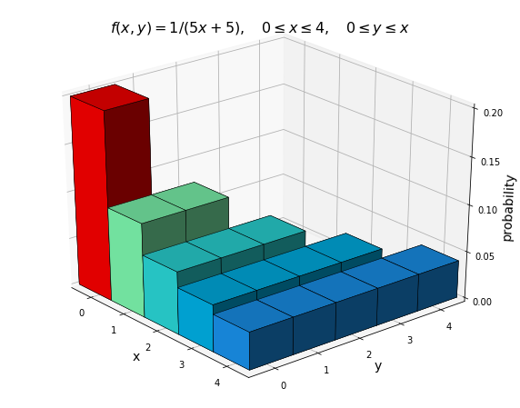

```python
fig = plt.figure(figsize=(10,8))
ax = fig.gca(projection = '3d')
ax.view_init(azim=-40, elev=28)
ax.bar3d(x-0.5, y-0.5, np.zeros_like(f), dx = 1, dy = 1, dz = f,color=colors,edgecolor="black",lw=0.5,shade=True)
ax.set_xlabel('x', size=14)
ax.set_xlim(-.5, 4.5)
ax.set_ylabel('y', size=14)
ax.set_ylim(-.5, 4.5)
ax.set_zlabel("probability", size=14,rotation=0)
ax.set_zticks(np.arange(0,0.25,0.05))
ax.set_title(r'$ f(x,y) = {1}/(5x+5), \quad 0 \leq x \leq 4, \quad 0 \leq y \leq x $', size=16)
```

## Plotting a bivariate normal pdf

Reference: Robert V. Hogg et al., *Probability and Statistical Inference* 9e, section 4.5.

I reconstruct example 3, which has $$\begin{align} \mu_X & = 10 && \mu_Y = 12 \\ \sigma_X^2 & = 9 && \sigma_Y^2 = 16 \\ && \rho = 0.6 \\ \end{align}$$

The conditional mean line is $\mathbb{E}(Y | x) = 0.8x +4$.

Then

$$h(y|x) = \frac{1}{4\sqrt{2\pi}\sqrt{1-0.6^2}} \exp\left(- \frac{\left[y - \mathbb{E}\left(y|x\right) \right]^2}{2\cdot16\cdot(1-0.6^2)}\right) $$

```python
def cond_mean(x):
    return 0.8*x + 4

def cond_pdf(x, y):
    return np.exp(- (y - cond_mean(x))**2 / (32*.64) ) / (4*np.sqrt(2*0.64*np.pi) )
```

$X$ is also normal, so we have

$$f_X(x) = N(10,9)$$

And

$$f(x, y) = h(y|x) \cdot f_X(x)$$

```python
def x_pdf(x):
    return norm.pdf(x,loc=10, scale=3)

def joint_pdf(x, y):
    return x_pdf(x) * cond_pdf(x, y)
```

In the graph below, you can see the elliptical shape of the contours as well as the fact that the conditional mean line meets the contours at vertical tangents. I wonder about the statistical properties of a line of best fit that sits along the major axis of these ellipses instead. I believe this would be the line that minimizes the squared distance between $(X,Y)$ and the nearest point to $(X,Y)$ on the fit line.

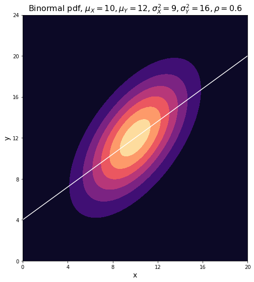

```python
u = np.linspace(0,20,601)
v = cond_mean(u)
x, y = np.meshgrid(u, np.linspace(0,24,721))
z = joint_pdf(x,y)

plt.figure(figsize=(8,9))
plt.title(r'Binormal pdf, $ \mu_X = 10, \mu_Y = 12, \sigma_X^2 = 9, \sigma_Y^2 = 16, \rho = 0.6 $', size=16)

plt.contourf(x, y, z,cmap='magma')
plt.plot(u,v, color="white")

plt.xticks(np.arange(0,21,4))
plt.yticks(np.arange(0,25,4))
plt.xlabel('x', size=14)
plt.ylabel('y', size=14)
```

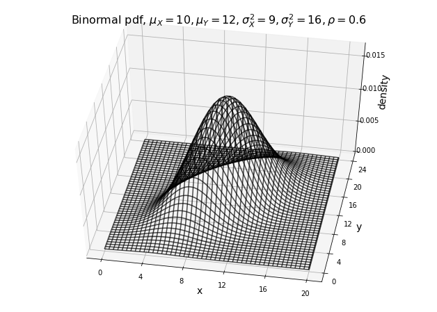

```python
#3D version of the same

fig = plt.figure(figsize=(11,8))
ax = fig.gca(projection = '3d')

ax.view_init(azim=-80, elev=50)
ax.plot_wireframe(x, y, z, linewidth=1.5,edgecolor="black",alpha=0.7)

plt.title(r'Binormal pdf, $ \mu_X = 10, \mu_Y = 12, \sigma_X^2 = 9, \sigma_Y^2 = 16, \rho = 0.6 $', size=16)
ax.set_xticks(np.arange(0,21,4))
ax.set_yticks(np.arange(0,25,4))
ax.set_zticks(np.arange(0,0.017,0.005))
ax.set_xlabel('x', size=14)
ax.set_ylabel('y', size=14)
ax.set_zlabel('density', size=14)
```

## Preparation for the Central Limit Theorem

Reference: Robert V. Hogg et al., *Probability and Statistical Inference* 9e, section 5.4.

Problem 13 reads,

> Let $X_1,X_2,\dots,X_8$ be a random sample from a distribution having pmf $f(x) = (x + 1)/6, x = 0,1,2$.
> 1. Use Exercise 5.4-9 to find the pmf of $W_1 = X_1 + X_2$.
> 2. What is the pmf of $W_2 = X_3 + X_4$?
> 3. Now find the pmf of $W = W_1 + W_2 = X_1 + X_2 +X_3 + X_4$.
> 4. Find the pmf of $Y = X_1 + X_2 + \cdots + X_8$.
> 5. Construct probability histograms for $X_1$, $W_1$, $W$, and $Y$. Are these histograms skewed or symmetric?

The result proven in 5.4-9 was the discrete convolution formula: The pmf of $W = X+Y$, where $X$ and $Y$ are independent random variables whose supports are subsets of the nonnegative integers, is

$$h(w)= \sum_{x=0}^{w} f(x) g(w-x), \qquad w = 0, 1, 2, \dots$$

#### Part A

$X_1$ and $X_2$ have the same pmf, $f(x)$. Note that the limits of the convolution summation do *not* account for places where $f(x) = 0$ (namely, anywhere not on the space), so we need to include this condition when defining `f(x)` in Python.

```python
def f(x):
    if 0 <= x <= 2: return (x+1)/6
    else: return 0

x1 = np.array([[i, f(i)] for i in range(3)])
x1
```

```
array([[0.        , 0.16666667],
       [1.        , 0.33333333],
       [2.        , 0.5       ]])
```

Then the pmf of $W_1$, which I call `h(w)`, will perform the summation.

```python
def h(w):
    return sum( [f(x)*f(w-x) for x in range(0,w+1) ] )
```

By inspection, the support of $W_1$ is $\{0, 1, 2, 3, 4\}$. Let’s get `h(w)` for those values and put it into an array, since in part E we will need to make a bar graph.

```python
a = np.array([[i, h(i)] for i in range(5)])
a
```

```
array([[0.        , 0.02777778],
       [1.        , 0.11111111],
       [2.        , 0.27777778],
       [3.        , 0.33333333],
       [4.        , 0.25      ]])
```

That is,

$$h(w) = \begin{cases} 1&/\,36, & w = 0 \\ 4&/\,36, & w = 1 \\ 10&/\,36, & w = 2 \\ 12&/\,36, & w = 3 \\ 9&/\,36, & w = 4 \\ 0 & & \text{elsewhere} \\ \end{cases}$$

(The “elsewhere” case corresponds to places where $f(x) = 0$ anyway, so we do not need to add cases to the definition of `h(w)`.)

#### Part B

$X_3$ and $X_4$ have the same pmf as $X_1$ and $X_2$, so the pmf of $W_2$ will be the same: $h(w)$.

#### Part C

$W_1$ and $W_2$ themselves meet the criteria for the convolution formula, so we can apply it again, this time replacing $h(w) = \sum_{x=0}^{w} f(x) f(w-x)$ with

$$u(v) = \sum_{w=0}^{v} h(w) h(v-w)$$

The support will be $\{0,1, \dots, 8\}$. Making a similar array:

```python
def u(v):
    return sum( [h(w)*h(v-w) for w in range(0,v+1) ] )

c = np.array([[i, u(i)] for i in range(9)])
c
```

```
array([[0.00000000e+00, 7.71604938e-04],
       [1.00000000e+00, 6.17283951e-03],
       [2.00000000e+00, 2.77777778e-02],
       [3.00000000e+00, 8.02469136e-02],
       [4.00000000e+00, 1.65123457e-01],
       [5.00000000e+00, 2.40740741e-01],
       [6.00000000e+00, 2.50000000e-01],
       [7.00000000e+00, 1.66666667e-01],
       [8.00000000e+00, 6.25000000e-02]])
```

We might check that the values of $u(v)$ actually sum to one.

```python
c[:,1].sum()
```

```
0.9999999999999999
```

Good enough.

#### Part D

By the same logic, we have

$$t(y) = \sum_{v=0}^{y} u(v) u(y-w), \qquad y = {0,1,\dots, 16}$$

```python
def t(y):
    return sum( [u(v)*u(y-v) for v in range(0,y+1) ] )

d = np.array([[i, t(i)] for i in range(17)])
d
```

```
array([[0.00000000e+00, 5.95374181e-07],
       [1.00000000e+00, 9.52598689e-06],
       [2.00000000e+00, 8.09708886e-05],
       [3.00000000e+00, 4.66773358e-04],
       [4.00000000e+00, 2.01712772e-03],
       [5.00000000e+00, 6.86823655e-03],
       [6.00000000e+00, 1.89710029e-02],
       [7.00000000e+00, 4.32194025e-02],
       [8.00000000e+00, 8.19461115e-02],
       [9.00000000e+00, 1.29658208e-01],
       [1.00000000e+01, 1.70739026e-01],
       [1.10000000e+01, 1.85442387e-01],
       [1.20000000e+01, 1.63387346e-01],
       [1.30000000e+01, 1.13425926e-01],
       [1.40000000e+01, 5.90277778e-02],
       [1.50000000e+01, 2.08333333e-02],
       [1.60000000e+01, 3.90625000e-03]])
```

#### Part E

Now, we will make histograms showing the distributions of $X_1$, $W_1$, $W$, and $Y$, which I have stored in the variables `x1`, `a`, `c`, and `d`, respectively.

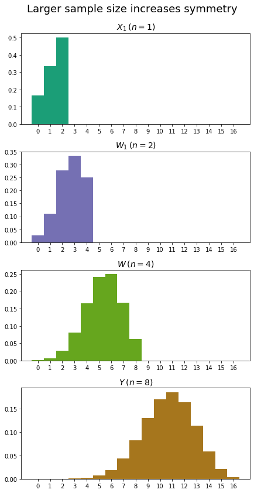

```python
distrs = [x1, a, c, d]
titles = [r"$X_1\:(n=1)$", r"$W_1\:(n=2)$", r"$W\:(n=4)$", r"$Y\:(n=8)$"]
colors = cm.get_cmap("Dark2")(np.linspace(0,.75,4))

fig, axs = plt.subplots(4, 1, sharex=True,figsize=(7, 14))
fig.subplots_adjust(hspace=0.3)
fig.suptitle('Larger sample size increases symmetry', size=18, y=0.93)

for i, dist in enumerate(distrs):
    axs[i].bar(*dist.T, color=colors[i], width=1)
    axs[i].set_title(titles[i],size=14)
    axs[i].set_xticks(np.arange(0,17))
    axs[i].set_xticklabels(np.arange(0,17))
    axs[i].tick_params(labelbottom=True)
```

As expected, the plot becomes more symmetrical as the sample size increases.

## Linear combination of independent geometric distributions

Reference: Robert V. Hogg et al., *Probability and Statistical Inference* 9e, section 5.4.

Problem 15 reads,

> Given a fair four-sided die, let $Y$ equal the number of rolls needed to observe each face at least once.
> 1. Argue that $Y = X_1 + X_2 + X_3 + X_4$, where $X_i$ has a geometric distribution with $p_i = (5−i)/4$, $i = 1,2,3,4$, and $X_1$, $X_2$, $X_3$, $X_4$ are independent.
> 2. Find the mean and variance of $Y$.
> 3. Find $\mathrm{P}(Y = y)$, $y = 4,5,6,7$.

#### Part A

Assign $X_1$ to whatever face appears first. Then $X_1$ has a geometric distribution with $p=1$. That is, $\mathrm{P}(X_1 = 0) = 1$.

Then, assign $X_2$ to the first different face to appear. The chance of getting a different face is $3/4$, and $X_2$, the number of trials until it comes up, is geometric with $p=3/4$.

Continuing in this manner, we have $X_3$ with $p=2/4$ and $X_4$ with $p=1/4$, so each $X_i$ is geometric with $p_i = (5−i)/4$.

Then $Y = X_1 + X_2 + X_3 + X_4 $.

#### Part B

From our [knowledge](https://en.wikipedia.org/wiki/Geometric_distribution) of the geometric distribution, we have

$$\begin{align} \mu_{X_i} & = \frac{1}{p_i} \\ \sigma_{X_i}^2 & = \frac{1-p}{p^2} \\ \end{align}$$

$Y$ is a linear combination of the $X_i$s with each $a_i = 1$, so

$$\begin{align} \mu_Y & = \sum_{i=1}^4 \mu_{X_i} = \frac{4}{4} + \frac{4}{3}+ \frac{4}{2}+ \frac{4}{1} = \bbox[4px, border: 1px solid black]{\frac{25}{3}} \\ \sigma_Y^2 & = \sum_{i=1}^4 \sigma_{X_i}^2 = 0 + \frac{1}{4}\left(\frac{4}{3}\right)^2 + \frac{2}{4}\left(\frac{4}{2}\right)^2 + \frac{3}{4}\left(\frac{4}{1}\right)^2 = \bbox[4px, border: 1px solid black]{\frac{130}{9} } \\ \end{align}$$

#### Part C

The mgf of the geometric distribution is

$$M_{X_i}(t) = \frac{p_i e^t}{1- (1-p_i)e^t}$$

$Y$ is a linear combination of the $X_i$s, so

$$\begin{align} M_Y (t) & = \prod_{i=1}^4 M_{X_i} \\ & = \frac{e^t}{1} \cdot \frac{\frac{3}{4} e^t}{1- \left(1-\frac{3}{4}\right)e^t}\cdot\frac{\frac{1}{2} e^t}{1- \left(1-\frac{1}{2}\right)e^t} \cdot\frac{\frac{1}{4} e^t}{1- \left(1-\frac{1}{4}\right)e^t} \\ & = \frac{3}{32} \cdot \frac{e^{4t}}{(1- \frac{3}{4}e^t)(1- \frac{1}{2}e^t)(1- \frac{1}{4}e^t)} \\ \end{align}$$

We can double-check (or perform) this simplification using sympy:

```python
from sympy.abc import p, t
Mx = p*sympy.exp(t) / (1- (1-p)*sympy.exp(t))
My = np.prod([Mx.subs(p,i) for i in [1, .75, .5, .25 ]])
My.nsimplify()
```

$\displaystyle \frac{3 e^{4 t}}{32 \left(1 - \frac{3 e^{t}}{4}\right) \left(1 - \frac{e^{t}}{2}\right) \left(1 - \frac{e^{t}}{4}\right)}$

Arranged like this, the mgf won’t help us evaluate the pmf $f(y)$, but we can use Taylor series to get it into a legible form. From $\frac{1}{1-az} = 1 + az + (az)^2 + (az)^3 + \dots$, we have

$$\begin{align} M_Y (t) = \frac{3}{32} e^{4t} & \left[1 + \left(\frac{3}{4}\right) e^t + \left(\frac{3}{4}\right)^2 e^{2t} + \left(\frac{3}{4}\right)^3 e^{3t} + \cdots \right] \\ \times & \left[1 + \left(\frac{1}{2}\right) e^t + \left(\frac{1}{2}\right)^2 e^{2t} + \left(\frac{1}{2}\right)^3 e^{3t} + \cdots \right] \\ \times & \left[1 + \left(\frac{1}{4}\right) e^t + \left(\frac{1}{4}\right)^2 e^{2t} + \left(\frac{1}{4}\right)^3 e^{3t} + \cdots \right] \\ \end{align}$$

for $t \lt \ln(4/3)$.

The problem only asks us to evaluate the pmf of $y$ up to $f(7)$, which will correspond in the mgf to the coefficient of $e^{7t}$. Since we have $e^{4t}$ at the front, we won’t need any further terms than these to answer the question. All we need to do is multiply out the expression as shown above. We can do this using sympy.

```python
# First four terms of each Taylor series
one = sum([0.75**n *sympy.exp(n*t) for n in range(4)])
two = sum([0.5**n *sympy.exp(n*t) for n in range(4)])
three = sum([0.25**n *sympy.exp(n*t) for n in range(4)])

My2 = (3/32) * sympy.exp(4*t) *one*two*three
My2 = My2.expand()
My2
```

$\displaystyle 7.72476196289063 \cdot 10^{-5} e^{13 t} + 0.000566482543945313 e^{12 t} + 0.00291824340820313 e^{11 t} + 0.0131607055664063 e^{10 t} + 0.03460693359375 e^{9 t} + 0.0743408203125 e^{8 t} + 0.1318359375 e^{7 t} + 0.146484375 e^{6 t} + 0.140625 e^{5 t} + 0.09375 e^{4 t}$

Messy, but we can use sympy to pull out the coefficients and the $y$-values.

```python
y = My2.as_coefficients_dict().keys()
# Log out the exp, divide out t
y = [(sympy.log(i) / t).expand(force=True) for i in y]

f = list(My2.as_coefficients_dict().values())

pmf = np.stack([y,f]).T
pmf = pmf[pmf[:,0].argsort()]
pmf
```

```
array([[4, 0.0937500000000000],
       [5, 0.140625000000000],
       [6, 0.146484375000000],
       [7, 0.131835937500000],
       [8, 0.0743408203125000],
       [9, 0.0346069335937500],
       [10, 0.0131607055664063],
       [11, 0.00291824340820313],
       [12, 0.000566482543945313],
       [13, 7.72476196289063e-5]], dtype=object)
```

The values for $y>7$ are inaccurate because we didn’t include all the relevant terms from the Taylor expansion. But we have our answer.

```python
pmf[0:4,1] * 1024
```

```
array([96.0000000000000, 144.000000000000, 150.000000000000,
       135.000000000000], dtype=object)
```

That is,

$$\begin{align} f(4) & = 96 & /\:1024 \\ f(5) & = 144 & / \:1024 \\ f(6) & = 150 & / \:1024 \\ f(7) & = 135 & / \:1024 \\\end{align}$$

Let’s make a histogram of $f(y)$. We will need more terms from the Taylor series.

```python
r = 20
one = sum([0.75**n *sympy.exp(n*t) for n in range(r)])
two = sum([0.5**n *sympy.exp(n*t) for n in range(r)])
three = sum([0.25**n *sympy.exp(n*t) for n in range(r)])
My3 = (3/32) * sympy.exp(4*t) *one*two*three
My3 = My3.expand()
y = My3.as_coefficients_dict().keys()
y = [(sympy.log(i) / t).expand(force=True) for i in y]
f = list(My3.as_coefficients_dict().values())
pmf = np.stack([y,f]).T
pmf = pmf[pmf[:,0].argsort()]
pmf = pmf[:r] # Only the first r values are accurate
```

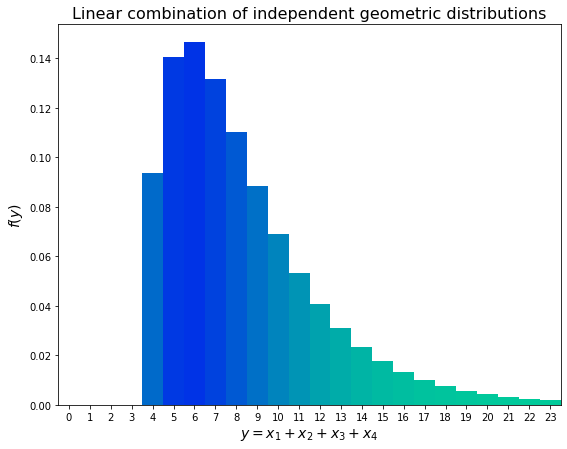

```python
plt.figure(figsize=(9,7))
colors = cm.get_cmap("winter")(0.8- 0.6*(pmf[:,1] / pmf[:,1].max()).astype(float))
plt.bar(*pmf.T,color=colors, width=1)
plt.xlabel(r'$ y = x_1 + x_2 + x_3 + x_4$',size=14)
plt.xticks(np.arange(r+4))
plt.xlim(-0.5, r+3.5)
plt.ylabel(r'$ f(y)$',size=14)
plt.title('Linear combination of independent geometric distributions',size=16)
```

## Reverse Chebyshev

Reference: Robert V. Hogg et al., *Probability and Statistical Inference* 9e, section 5.8.

Problem 7 reads,

> Suppose that $W$ is a continuous random variable with mean 0 and a symmetric pdf $f(w)$ and cdf $F(w)$, but for which the variance is not specified (and may not exist). Suppose further that $W$ is such that $$\mathrm{P}\left(\left|W − 0\right| \lt k\right) = 1 − \frac{1}{k^2}$$ for $k \geq 1$. (Note that this equality would be equivalent to the equality in Chebyshev’s inequality if the variance of $W$ were equal to 1.) Then the cdf satisfies $$F(w) − F(−w) = 1 − \frac{1}{w^2}, \qquad w \geq 1.$$ Also, the symmetry assumption implies that $$F(−w) = 1 − F(w).$$
> 1. Show that the pdf of $W$ is $$f(w) = \begin{cases}\frac{1}{\left|w\right|^3}, & \left|w\right| \gt 1 \\ 0, & \left|w\right| \leq 1.\end{cases}$$
> 2. Find the mean and the variance of $W$ and interpret your results.
> 3. Graph the cdf of $W$.

#### Part A

For $w \geq 1$, we have $$ F(w) - F(-w) = F(w) - \left[1-F(w)\right] = 2F(w) -1 = 1 − \frac{1}{w^2} \\ \implies F(w) = 1 − \frac{1}{2w^2} \\ \implies \bbox[4px, border: 1px solid black]{ f(w) = \frac{1}{w^3}, \qquad w \geq 1 } $$

For negative $w$, we apply the symmetry assumption: $$F(-w) = 1- F(w) \\ \begin{align}\implies F(w) & = 1 - F(\left|w\right|) \\ & = 1 - ( 1 - \frac{1}{2\left|w\right|^2}) \\ & = \frac{1}{2w^2}\end{align} \\ \implies \bbox[4px, border: 1px solid black]{f(w) = -\frac{1}{w^3}, \qquad w \leq -1} $$

Notice that $F(-1) = F(1) = 1/2$, meaning that no probability is gained on $ -1 \lt w \lt 1$. This implies

$$\bbox[4px, border: 1px solid black]{f(w) = 0, \qquad -1 \lt w \lt 1 \quad}$$

Put the three boxed portions together to get

$$\bbox[4px, border: 1px solid black]{ f(w) = \begin{cases}\frac{1}{\left|w\right|^3}, & \left|w\right| \geq 1 \\ 0, & \left|w\right| \lt 1\end{cases} }$$

(I don’t know why the textbook swaps the inequalities for $\left|w\right|= 1$, but these are zero-probability events anyhow.)

#### Part B

Note that we do *not* get $\mu_W = 0$ for free from the symmetry assumption; a distribution can be [symmetric with undefined](https://en.wikipedia.org/wiki/Cauchy_distribution#Mean) $\mu$. Here is the mean: $$\begin{align} \mathbb{E}\left(W\right) & = \int_{\infty}^{\infty} w \cdot f(w) \, dw \\ & = \int_{1}^{\infty} w^{-2} \,dw + \int_{-\infty}^{-1} - w^{-2} \, dw \\ & = \left[-\frac{1}{w}\right]_{1}^{\infty} + \left[\frac{1}{w}\right]_{-\infty}^{-1} \\ & = 1 - 1 = 0 & \implies \bbox[4px, border: 1px solid black]{ \mu_W = 0 } \end{align} $$

And the standard deviation:

$$\begin{align} \mathbb{E}\left[(W - \mu_W)^2\right] & = \int_{\infty}^{\infty} (w-0)^2 \cdot f(w) \,dw \\ & = \int_{1}^{\infty} \frac{1}{w} \,dw + \int_{-\infty}^{-1} \frac{1}{w} \,dw \\ & = \bigl[\ln\left|w\right|\bigr]_{1}^{\infty} + \bigl[\ln\left|w\right|\bigr]_{-\infty}^{-1} \\ & = \infty - \infty & \implies \bbox[4px, border: 1px solid black]{ \sigma_W^2 \text{ undefined} }\end{align} \\ $$

#### Part C

Graphing the cdf.

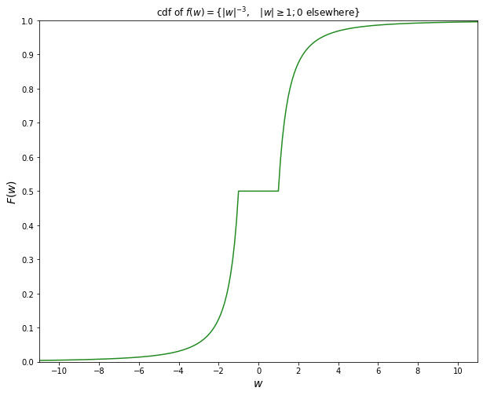

```python
def cdf(w):
    if w <= -1: return 0.5 * w**-2
    if -1 < w < 1: return 0.5
    if w >= 1: return 1- 0.5 * w**-2

cdf = np.vectorize(cdf)

t = np.linspace(-11, 11, 221)

plt.figure(figsize=(10,8))
plt.title(r'cdf of $f(w) = \{\left|w\right|^{-3}, \quad \left|w\right| \geq 1; 0 \mathrm{\ elsewhere}\}$')
plt.plot(t,cdf(t), color='forestgreen')
plt.xlabel(r'$w$', size=14)
plt.xlim(-11,11)
plt.xticks(np.arange(-10,11, 2))
plt.ylim(0,1)
plt.yticks(np.arange(0,1.01,.1))
plt.ylabel(r'$F(w)$', size=14)
```

## *q–q* plot

Reference: Robert V. Hogg et al., *Probability and Statistical Inference* 9e, section 6.3.

Problem 13 reads,

> Some measurements (in mm) were made on specimens of the spider *Sosippus floridanus,* which is native to Florida. Here are the lengths of nine female spiders and nine male spiders.

> [data below]
> 1. Construct a *q–q* plot of the female spider lengths. Do they appear to be normally distributed?
> 2. Construct a *q–q* plot of the male spider lengths. Do they appear to be normally distributed?

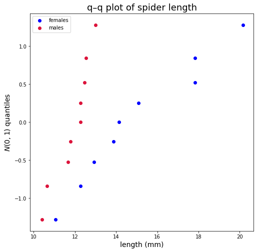

```python
females = np.array('11.06 13.87 12.93 15.08 17.82 14.14 12.26 17.82 20.17'.split())
males = np.array('12.26 11.66 12.53 13.00 11.79 12.46 10.65 10.39 12.26'.split())

females = np.vectorize(float)(females)
males = np.vectorize(float)(males)

females.sort()
males.sort()

pcs = np.linspace(0, 1, len(females)+2)[1:-1]

npcs = norm.ppf(pcs)

plt.figure(figsize=(8,8))

plt.scatter(females, npcs, color="blue", label="females")
plt.scatter(males, npcs, color="crimson", label="males")
plt.title(r'q–q plot of spider length', size=18)
plt.ylabel(r'$N(0,1)$ quantiles', size=14)
plt.xlabel('length (mm)', size=14)
plt.legend()
```

Both sets of points follow roughly straight lines, suggesting that the data are normally distributed.

## Maximum likelihood estimation

Reference: Robert V. Hogg et al., *Probability and Statistical Inference* 9e, section 6.4.

Problem 19 reads,

> Let the independent normal random variables $Y_1,Y_2 ,\dots,Y_n$ have the respective distributions $N(\mu,\gamma^2 x_i^2), i = 1, 2, \dots ,n$, where $x_1,x_2 ,\dots, x_n$ are known but not all the same and no one of which is equal to zero. Find the maximum likelihood estimators for $\mu$ and $\gamma^2$.

It’s not stated in the problem, but clear from the solution given that we also have a sample of size $n$ composed of one sample from each distribution, and we know which comes from where—not realistic, but theoretically interesting.

For our likelihood function, we have

$$\begin{align} L(\mu, \gamma) &= \prod_{i=1}^n \frac{1}{\sqrt{ 2\pi\gamma^2x_i^2}}\exp\left[-\frac{\left( y_i - \mu \right)^2}{2\gamma^2 x_i^2}\right] \\ &= \left(\frac{1}{\sqrt{ 2\pi\gamma^2}}\right)^n \frac{1}{\prod x_i}\exp\left[-\sum \frac{\left( y_i - \mu \right)^2}{2\gamma^2 x_i^2}\right] \\ \end{align}$$

Our goal is to maximize this, so we can take the logarithm without affecting the location of the maximum:

$$\begin{align} \ln\left[L(\mu, \gamma)\right] &= -\frac{n}{2}\ln(2\pi) - n\ln\gamma - \sum\ln(x_i) -\sum \frac{\left( y_i - \mu \right)^2}{2\gamma^2x_i^2} & \\ \frac{\partial}{\partial \mu} \ln\left[L(\mu, \gamma)\right] &= \sum \frac{\left( y_i - \mu \right)}{\gamma^2 x_i^2} = 0 & \\ &= \mu \sum \frac{1}{x_i^2} + \sum \frac{y_i}{x_i^2} & \implies \bbox[4px, border: 1px solid black]{ \hat\mu = \frac{\sum y_i \big/ x_i^2}{\sum 1 \big/ x_i^2} }\\ \frac{\partial}{\partial \gamma} \ln\left[L(\mu, \gamma)\right] &= -\frac{n}{\gamma} + \frac{1}{\gamma^3} \sum \frac{\left( y_i - \mu \right)^2}{x_i^2} = 0 \\ &= -n\gamma^2 + \sum \frac{\left( y_i - \mu \right)^2}{x_i^2} & \implies \bbox[4px, border: 1px solid black]{ \widehat{\gamma^2} = \frac{1}{n}\sum\frac{\left(y_i - \hat\mu\right)^2}{x_i^2} } \end{align}$$

## Basu’s theorem

Reference: Robert V. Hogg et al., *Probability and Statistical Inference* 9e, section 6.7.

Problem 9 reads,

> Let $X_1 ,X_2 , \dots ,X_n$ be a random sample from $N(\theta_1 ,\theta_2)$. Show that the sufficient statistics $Y_1 = \bar X$ and $Y_2 = S^2$ are independent of the statistic $$ Z = \sum_{i=1}^{n−1} \frac{\left(X_{i+1} − X_i\right)^2}{S^2}$$ because Z has a distribution that is free of $\theta_1$ and $\theta_2$.

The mgf of $Z$ is

$$\begin{align} \mathbb{E}(e^{tZ}) = \int_{-\infty}^{\infty} \int_{-\infty}^{\infty} \dotsi \int_{-\infty}^{\infty} {\exp\left[ t \sum_{i=1}^{n−1} \frac{\left(x_{i+1} − x_i\right)^2}{S^2}\right]} \frac{1}{\left(\sqrt{2 \pi \theta_2}\right)^n} {\exp \left[-\frac{\sum_{i=1}^{n} \left(x_{i} − \theta_1 \right)^2}{2\theta_2}\right]} {dx_1 dx_2 \dots dx_n} \end{align}$$

As the text suggests, make the substitution $w_i = \frac{(x_i − \theta_1 )}{ \sqrt{\theta_2}}$. We also know $S^2 = \frac{1}{n-1}\sum_{i=1}^{n} (x_{i} - \theta_1)^2$.

Then, working with the expression for $e^{tZ}$ (the first $\exp$ in the integral), we have

$$\begin{align} \exp\left[ t \sum_{i=1}^{n−1} \frac{\left(x_{i+1} − x_i\right)^2}{S^2}\right] & = \exp\left[ t \frac{ \sum_{i=1}^{n−1} \bigl( (x_{i+1} - \theta_1)+ (\theta_1 − x_i)\bigr)^2}{\frac{1}{n-1}\sum_{i=1}^{n} (x_{i} - \theta_1)^2}\right] \\ & = \exp\left[ t \frac{\sum_{i=1}^{n−1} \left( \sqrt{\theta_2} w_{i+1} + \sqrt{\theta_2}w_i\right )^2}{\frac{1}{n-1}\sum_{i=1}^{n} ( \sqrt{\theta_2} w_i)^2} \right] \\ & = {\exp\left[ t (n-1) \frac{\sum_{i=1}^{n−1} \left( w_{i+1} + w_i\right )^2}{\sum_{i=1}^{n} (w_i)^2} \right]} \end{align}$$

The other exponential expression is

$$\begin{align} \exp \left[-\frac{\sum_{i=1}^{n} \left(x_{i} − \theta_1 \right)^2}{2\theta_2}\right] & = \exp \left[-\frac{\sum_{i=1}^{n} \left(\sqrt{\theta_2} w_i\right)^2}{2\theta_2}\right] \\ & = {\exp \left[-\frac{1}{2} \sum_{i=1}^{n} w_i^2\right]} \end{align}$$

Finally, from $x_i = \sqrt{\theta_2} w_i + \theta_1$, we have $dx_i = \sqrt{\theta_2} dw_i$, so $dx_1 dx_2 \dots dx_n = {\left(\sqrt{\theta_2}\right)^n dw_1 dw_2 \dots dw_n}$. $\left(\sqrt{\theta_2}\right)^n$ cancels with the one in the denominator, and the final expression for the mgf is

$$\begin{align} \mathbb{E}(e^{tZ}) = \int_{-\infty}^{\infty} \int_{-\infty}^{\infty} \dotsi \int_{-\infty}^{\infty} {\exp\left[ t (n-1) \frac{\sum_{i=1}^{n−1} \left( w_{i+1} + w_i\right )^2}{\sum_{i=1}^{n} (w_i)^2} \right]} \frac{1}{\left(\sqrt{2 \pi}\right)^n} {\exp \left[-\frac{1}{2} \sum_{i=1}^{n} w_i^2\right]} {dw_1 dw_2 \dots dw_n} \end{align}$$

which is free of both parameters and therefore, by Basu’s theorem, independent of $Y_1$ and $Y_2$.

## Linear regression, multiple regression, and related confidence intervals

References:

- Robert V. Hogg et al., *Probability and Statistical Inference* 9e, section 7.6.
- Gilbert Strang, *Linear Algebra and Its Applications* 4e, section 3.3.

**Problem 3** reads,

> For the data given in Exercise 6.5-3 [data below], with the usual assumptions,
> 1. Find a 95% confidence interval for $\mu(x)$ when $x =$ 68, 75, and 82.
> 2. Find a 95% prediction interval for $Y$ when $x =$ 68, 75, and 82.

I created some simple Python functions useful in answering this sort of problem.

```python
from scipy.stats import t

def beta(x, y):
    return y @ (x- x.mean()) / sum((x - x.mean())**2)

def line(x, y):
    def mu(z):
        return y.mean() + beta(x, y) * (z - x.mean())
    return mu

def sigma2(x, y):
    mu = line(x,y)
    residuals = y - mu(x)
    return sum(residuals**2) / len(y)

def c(x, y):
    n = len(y)
    def f(z):
        return np.sqrt( n*sigma2(x,y) / (n-2)) * np.sqrt( 1/n + (z - x.mean())**2/sum((x - x.mean())**2))
    return f

def d(x, y):
    n = len(y)
    def f(z):
        return np.sqrt( n*sigma2(x,y) / (n-2)) * np.sqrt(1+ 1/n + (z - x.mean())**2/sum((x - x.mean())**2))
    return f
```

```python
x, y = np.vectorize(int)(np.array('70 87 74 79 80 88 84 98 80 96 67 73 70 83 64 79 74 91 82 94'.split())).reshape(10,2).T
pred = line(x, y)

pt_a = []
for i in [68, 75, 82]:
    pt_a.append(( pred(i) - c(x,y)(i) * t.isf(.025, len(y)-2), pred(i) + c(x,y)(i) * t.isf(.025, len(y)-2) ))
pt_a
```

```
[(75.28277625314745, 85.11336367447619),
 (83.83843759007924, 90.77724395394971),
 (89.10712853220839, 99.72809462822586)]
```

```python
pt_b = []
for i in [68, 75, 82]:
    pt_b.append(( pred(i) - d(x,y)(i) * t.isf(.025, len(y)-2), pred(i) + d(x,y)(i) * t.isf(.025, len(y)-2)) )
pt_b
```

```
[(68.20615316762974, 92.1899867599939),
 (75.83253186012546, 98.78314968390349),
 (82.258368742456, 106.57685441797825)]
```

These match the answers in the text.

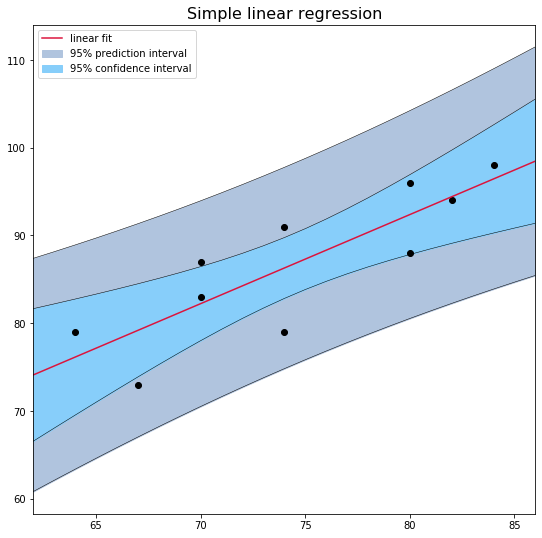

```python
def CI(i):
    return ( pred(i) - c(x,y)(i) * t.isf(.025, len(y)-2), pred(i) + c(x,y)(i) * t.isf(.025, len(y)-2) )
def PI(i):
    return ( pred(i) - d(x,y)(i) * t.isf(.025, len(y)-2), pred(i) + d(x,y)(i) * t.isf(.025, len(y)-2) )

x_plot = np.arange(62, 87)
CI_lower, CI_higher = CI(x_plot)
PI_lower, PI_higher = PI(x_plot)

plt.figure(figsize = (9, 9))
plt.fill_between(x_plot,PI_lower, PI_higher, color='lightsteelblue', label = '95% prediction interval')
plt.fill_between(x_plot,CI_lower, CI_higher, color='lightskyblue', label = '95% confidence interval')
plt.scatter(x,y, color='black')
plt.plot(x_plot, pred(x_plot), color = 'crimson', label = 'linear fit')

for i in [CI_lower, CI_higher, PI_lower, PI_higher]:
    plt.plot(x_plot, i, color = 'black', lw=0.5)

plt.title('Simple linear regression', size=16)
plt.xlim(62, 86)
plt.legend()
```

**Problem 9** reads,

> By the method of least squares, fit the cubic equation $y = \beta_1 + \beta_2 x + \beta_3 x^2 + \beta_4 x^3$ to the following 10 observed data points (x,y):

> [data below]

This is hella easy using linear algebra. We have the overdetermined system

$$X \beta = \begin{bmatrix} x_1^0 & x_1^1 & x_1^2 & x_1^3 \\ \vdots & \vdots & \vdots & \vdots \\ x_{10}^0 & x_{10}^1 & x_{10}^2 & x_{10}^3 \\ \end{bmatrix} \begin{bmatrix} \beta_1 \\ \beta_2 \\ \beta_3 \\ \beta_4 \\ \end{bmatrix} = \begin{bmatrix} y_1 \\ \vdots \\ y_{10} \\ \end{bmatrix} = y$$

A least-squares solution comes from solving the normal equations $X^T X \hat \beta = X^T y$.

```python
x, y = np.array([(0, 1), (-1, -3), (0, 3), (1, 3), (-1, -1), (2, 10), (0, 0), (-2, -9), (-1, -2), (2, 8)]).T
X = np.stack([x**n for n in range(4)]).T
b = np.linalg.solve(X.T @ X, X.T @ y)
b
```

```
array([ 1.10366826,  2.03269537, -0.29744817,  0.62041467])
```

```python
# You can also use this:
# b = np.linalg.lstsq(X, y)[0]
```

The solution is $y= 1.104 + 2.033 x - 0.297 x^2 + 0.620 x^3$.

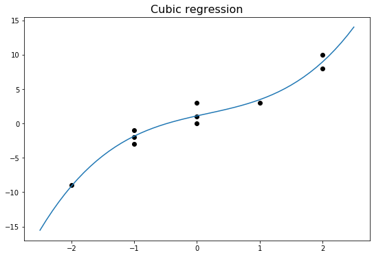

```python
plt.figure(figsize = (9, 6))
plt.scatter(x,y, color='black')
x_plot = np.stack([np.linspace(-2.5, 2.5, 51)**n for n in range(4)]).T
plt.plot(x_plot[:,1], x_plot @ b)
plt.title('Cubic regression', size=16)
```

**Problem 11** gives rainfall and blueberry production from NOAA and asks us to compare linear and quadratic models.

```python
# Linear model
x, y = np.array([(4.11, 56.2), (5.49, 45.3), (5.35, 31.0), (6.53, 30.1), (5.18, 40.0), (4.89, 38.5), (2.09, 50.0), (1.40, 45.8), (4.52, 45.9), (1.11, 32.4), (0.60, 18.2), (3.80, 56.1)]).T
X = np.stack([x**n for n in range(2)]).T
b_lin = np.linalg.solve(X.T @ X, X.T @ y)
b_lin
```

```
array([37.68335454,  0.82759586])
```

```python
# Quadratic model
X = np.stack([x**n for n in range(3)]).T
b_quad = np.linalg.solve(X.T @ X, X.T @ y)
b_quad
```

```
array([12.84503218, 22.56550378, -3.21798324])
```

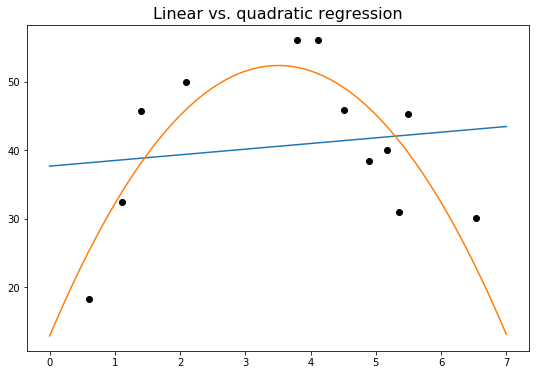

```python
plt.figure(figsize=(9,6))
plt.scatter(x,y, color='black')
x_plot = np.stack([np.linspace(0, 7, 71)**n for n in range(3)]).T
plt.plot(x_plot[:,1], x_plot[:,:2] @ b_lin)
plt.plot(x_plot[:,1], x_plot @ b_quad)
plt.title('Linear vs. quadratic regression', size=16)
```

The quadratic model clearly fits the data better.

For any serious task, you should create these linear models with [scikit-learn](https://scikit-learn.org/stable/modules/generated/sklearn.linear_model.LinearRegression.html) instead.

## The Wilcoxon signed rank statistic

Reference: Robert V. Hogg et al., *Probability and Statistical Inference* 9e, section 8.4.

Here are two Python functions that compute the signed ranks of input data and the (exact) distribution of the Wilcoxon signed rank statistic $W$ for a given $n$.

```python
def signed_ranks(x, m = None):
    if m is None:
        m = np.median(x)
    ranks = rankdata(np.abs(x-m))
    signs = np.sign(x - m)
    return ranks * signs

def wilcoxon_mgf(n, t = None):
    if t is None:
        t = sympy.symbols('t')
    out = np.product([0.5 * (sympy.exp(-k * t) + sympy.exp(k * t) ) for k in np.arange(1, n+1)])
    return out.expand()
```

Using some data from one of my houseplants, I compare a bootstrap distribution of $W$ to its normal approximation. The underlying data are skewed to the right, so $W= 70$ and its distribution is centered there.

```python
# Aretha's leaf length data
leaves = np.vectorize(int)(np.array('56 48 61 61 50 69 67 55 49 52 53 67 66 53 44 36 49 64 50 61 52 72 54 53 51 56 42 34 71 51 35 47 77 51 45 61 50 44 35 45 60 91 58'.split()))
signed_ranks(leaves)
```

```
array([ 13. , -18.5,  24.5,  24.5, -13. ,  35. ,  33.5,   8.5, -16.5,
        -5. ,   0. ,  33.5,  32. ,   0. , -28.5, -36. , -16.5,  30.5,
       -13. ,  24.5,  -5. ,  40.5,   5. ,   0. ,  -8.5,  13. , -30.5,
       -40.5,  38. ,  -8.5, -38. , -20. ,  42. ,  -8.5, -24.5,  24.5,
       -13. , -28.5, -38. , -24.5,  21. ,  43. ,  18.5])
```

```python
signed_ranks(leaves).sum()
```

```
70.0
```

```python
# Bootstrap some Ws
W = []
np.random.seed(780)
for i in range(5000):
    u = np.random.choice(leaves, len(leaves))
    u = signed_ranks(u, np.median(leaves))
    W.append(u.sum())
W = np.array(W)
W[:25]
```

```
array([ 251.,  102.,  116.,   32.,  172.,  235.,   81.,   -8.,   44.,
        -69.,  155.,  148.,   84., -193.,  162.,  109.,  255.,  159.,
         61.,    6.,  220.,  106.,  109.,    6.,    5.])
```

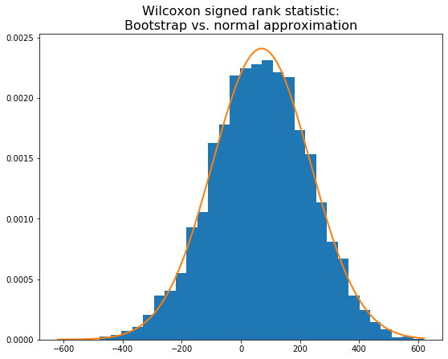

```python
plt.figure(figsize=(9,7))

lim = np.abs(W).max()
x_plot = np.linspace(-lim,lim, 201)
n = len(leaves)

plt.hist(W, density=True, bins=30)
plt.title('Wilcoxon signed rank statistic:\nBootstrap vs. normal approximation', size=16)
plt.plot(x_plot, norm.pdf(x_plot, scale= np.sqrt(n*(n+1)*(2*n+1)/6), loc=signed_ranks(leaves).sum()), lw=2)
```

Computing the “exact” distribution of $W$ for $n = 15$ using sympy:

```python
n = 15
mgf = wilcoxon_mgf(n, 1)
```

```python
# Output is really long
print(mgf)
```

```python
y = mgf.as_coefficients_dict().values()
y = np.array([i for i in y])
x = mgf.as_coefficients_dict().keys()
x = np.array([sympy.ln(i).simplify() for i in x])

pmf = np.stack([x, y]).T
pmf = pmf[pmf[:,0].argsort()]
pmf[55:65]
```

```
array([[-10, 0.0212097167968750],
       [-8, 0.0214843750000000],
       [-6, 0.0217285156250000],
       [-4, 0.0218505859375000],
       [-2, 0.0219421386718750],
       [0, 0.0220336914062500],
       [2, 0.0219421386718750],
       [4, 0.0218505859375000],
       [6, 0.0217285156250000],
       [8, 0.0214843750000000]], dtype=object)
```

```python
pmf.sum(axis=0)
```

```
array([0, 1.00000000000000], dtype=object)
```

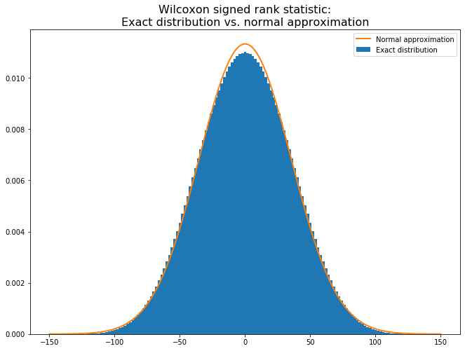

```python
plt.figure(figsize=(11,8))

lim = 150
x_plot = np.linspace(-lim,lim, 201)

plt.title('Wilcoxon signed rank statistic:\nExact distribution vs. normal approximation', size=16)

# Need to halve the coefficients in pmf because the bins have width 2
plt.bar(pmf.T[0], pmf.T[1]/2, width=2, label='Exact distribution')
plt.plot(x_plot, norm.pdf(x_plot, scale = np.sqrt(n*(n+1)*(2*n+1)/6)),
         lw=2, label='Normal approximation', color='tab:orange')
plt.legend()
```

## Likelihood ratio test

Reference: Robert V. Hogg et al., *Probability and Statistical Inference* 9e, section 8.7.

Problem 11:

> Let $Y_1, Y_2, \dots, Y_n$ be $n$ independent random variables with normal distributions $\mathrm{N}(\beta x_i,\sigma^2)$, where $x_1, x_2 , \dots ,x_n$ are known and not all equal and $\beta$ and $\sigma^2$ are unknown parameters.
> 1. Find the likelihood ratio test for $H_0: \beta = 0$ against $H_1: \beta \ne 0$.
> 2. Can this test be based on a statistic with a well-known distribution?

#### Part A

The maximum likelihood estimator for the variance is

$$ \widehat{\sigma^2} = \frac{\sum_{y=i}^n \left(y_i - \hat\beta x_i\right) ^2 }{n}$$

The maximum likelihood estimator for $\beta$ comes from solving $x \beta = y$ by least squares:

$$x^T x \hat{\beta} = x^T y \implies \hat\beta = \frac{x^T y}{x^T x} = \frac{\sum x_i y_i}{\sum x_i^2 }$$

Then

$$\begin{align} L( \hat \Omega ) & = \left(2 \pi \widehat{\sigma^2} \right)^{-n/2} \exp\left[- \frac{\sum (y_i - \hat\beta x_i) ^2 }{2 \sum (y_i - \hat\beta x_i) ^2 \big/ n}\right] \\ & = \left(\frac{2 \pi e}{n} \sum \left(y_i - \hat\beta x_i\right)^2 \right)^{-n/2} \end{align}$$

Under $H_0$, $\beta = 0$, so we replace $\widehat{\sigma^2}$ with $\sum y_i^2 / n$, and

$$\begin{align} L( \hat \omega ) & = \left(\frac{2 \pi}{n} \sum y_i^2 \right)^{-n/2} \exp\left[- \frac{\sum y_i^2 }{2 \sum y_i^2 \big/ n}\right] \\ & = \left(\frac{2 \pi e}{n} \sum y_i^2 \right)^{-n/2} \end{align}$$

The likelihood ratio is

$$\begin{align} \lambda = \frac{L( \hat \omega ) }{L( \hat \Omega )} & = \left[ \frac{\sum y_i^2 } {\sum\left(y_i - \hat\beta x_i\right)^2 } \right]^{-n/2}\\ & = \left[ \frac{\sum y_i^2 - 2 \hat\beta x_i y_i + \hat{\beta}^2 x_i^2} {\sum\left(y_i - \hat\beta x_i\right)^2 } + \frac{\sum 2 \hat\beta x_i y_i - \hat{\beta}^2 x_i^2} {\sum\left(y_i - \hat\beta x_i\right)^2 } \right]^{-n/2} \end{align}$$

The first term is one because the numerator is the expansion of the denominator. In the second term’s numerator, $$ 2\hat\beta \sum x_i y_i = 2 \frac{x^T y}{x^T x} x^T y = 2 \frac{x^T y}{x^T x} \frac{x^T y}{x^T x} x^T x = 2 \hat{\beta}^2 x^T x = 2\hat{\beta}^2 \sum x_i^2 $$

So $$\begin{align} \lambda & = \left[ 1 + \hat{\beta}^2 \frac{\sum x_i^2} {\sum\left(y_i - \hat\beta x_i\right)^2 } \right]^{-n/2} \leq k \end{align}$$

#### Part B

This is a function of

$$t = \frac{c \hat\beta}{\sqrt{\sum\left(y_i - \hat\beta x_i\right)^2 \big / (n-1)}}$$

$\hat\beta$ is normal because it is a linear combination of normally distributed variables $Y_i$, and the quantity in the denominator represents the sample variance of the $Y_i$s. Therefore, for some value of $c$ (that which transforms $\hat\beta$ to have variance 1), the random variable

$$T = \frac{c \hat\beta}{\sqrt{\sum\left(Y_i - \hat\beta x_i\right)^2 \big / (n-1)}}$$

has a $t$ distribution with $n-1$ degrees of freedom.

## Chi-square goodness-of-fit tests

Reference: Robert V. Hogg et al., *Probability and Statistical Inference* 9e, sections 9.1 and 9.2.

Problem 9.1.9 reads,

> Let $X$ equal the amount of butterfat (in pounds) produced by 90 cows during a 305-day milk production period following the birth of their first calf. Test the hypothesis that the distribution of $X$ is $N(\mu,\sigma^2)$, using $k = 10$ classes of equal probability. You may take $\bar x = 511.633$ and $s_x = 87.576$ as estimates of $\mu$ and $\sigma$, respectively. [data below]

We can use the Pandas library to classify the data as requested.

```python
x = np.vectorize(int)(np.array("486 537 513 583 453 510 570 500 458 555 618 327 350 643 500 497 421 505 637 599 392 574 492 635 460 696 593 422 499 524 539 339 472 427 532 470 417 437 388 481 537 489 418 434 466 464 544 475 608 444 573 611 586 613 645 540 494 532 691 478 513 583 457 612 628 516 452 501 453 643 541 439 627 619 617 394 607 502 395 470 531 526 496 561 491 380 345 274 672 509".split()))

# Normalize the data and bin them according to deciles of the normal distribution
z = (x - x.mean()) / x.std(ddof=1)
binned = pd.cut(norm.cdf(z), np.linspace(0, 1,11))
counts = pd.value_counts(binned).to_numpy()
counts
```

```
array([13, 11, 10, 10,  9,  9,  8,  7,  7,  6], dtype=int64)
```

```python
# If the data are normally distributed, each bin will contain n/10 = 9 values
E = len(x) / 10

# q-score
q = sum((counts - E)**2 /E)

# p-value
# df = k - 1 - 2 = 7
p = chi2.sf(q, 7)

q, p
```

```
(4.444444444444445, 0.7273963628862189)
```

With $p = 0.727$, we fail to reject $H_0$.

Problem 9.2.3 reads,

> Each of two comparable classes of 15 students responded to two different methods of instructions, giving the following scores on a standardized test:

> [data below]

> Use a chi-square test with $\alpha = 0.05$ to test the equality of the distributions of test scores by dividing the combined sample into three equal parts (low, middle, high).

First, I define a few functions that take in a contingency table and return predicted values under $H_0$ (no interaction) and a Q score that can be compared to critical values from a $\chi^2$ distribution.

```python
def contingency_pred(x, prop=False):
    total = x.sum()
    out =  np.outer(*[x.sum(axis=i)/total for i in range(len(x.shape))[::-1]])
    if prop: return out
    return out * total

def q_score(x):
    c = contingency_pred(x)
    return ((x - c)**2 /c).sum()
```

Use the Pandas library’s `qcut()` function to bin the data as described.

```python
# 9.2.3
u = np.vectorize(int)(np.array('91 42 39 62 55 82 67 44 51 77 61 52 76 41 59'.split()))
v = np.vectorize(int)(np.array('80 71 55 67 61 93 49 78 57 88 79 81 63 51 75'.split()))
x = np.stack((u, v))
x
```

```
array([[91, 42, 39, 62, 55, 82, 67, 44, 51, 77, 61, 52, 76, 41, 59],
       [80, 71, 55, 67, 61, 93, 49, 78, 57, 88, 79, 81, 63, 51, 75]])
```

```python
x_binned = pd.qcut(x.flatten(), q=3, labels=['low','mid','high']).get_values().reshape(x.shape)
x_binned
```

```
array([['high', 'low', 'low', 'mid', 'low', 'high', 'mid', 'low', 'low',
        'high', 'mid', 'low', 'high', 'low', 'mid'],
       ['high', 'mid', 'low', 'mid', 'mid', 'high', 'low', 'high', 'mid',
        'high', 'high', 'high', 'mid', 'low', 'mid']], dtype=object)
```

```python
x_grouped = dict(zip(['Group I','Group II'], [pd.value_counts(i).loc[['low','mid','high']].values for i in x_binned]))
x_grouped = pd.DataFrame(x_grouped)
x_grouped.index = ['low','mid','high']
x_grouped
```

|  | Group I | Group II |
| --- | --- | --- |
| low | 7 | 3 |
| mid | 4 | 6 |
| high | 4 | 6 |

```python
# Under the null hypothesis, each bin contains 5 students
contingency_pred(x_grouped.to_numpy())
```

```
array([[5., 5.],
       [5., 5.],
       [5., 5.]])
```

```python
q_score(x_grouped.to_numpy())
```

```
2.4000000000000004
```

```python
# Critical value for alpha = 0.05
chi2.isf(.05, 2)
```

```
5.991464547107983
```

Fail to reject $H_0$, since $q = 2.40 \lt 5.99 = \chi_{0.05}^2 (2)$.

In the above examples, the columnwise and rowwise sums of the contingency tables were homogeneous (that is, under $H_0$ we expect the same number of subjects in each cell). However, the functions `contingency_pred()` and `q_score()` provided above work even in the nonhomogenous case.

## Two-way ANOVA

Reference: Robert V. Hogg et al., *Probability and Statistical Inference* 9e, section 9.4.

Problem 9 gives us data from a 3-by-3 design comparing the oxygen uptake of nonsmokers, moderate smokers, and heavy smokers on bicycle, treadmill, and step tests. We are asked to test for interaction, row, and column effects using a two-way ANOVA.

For rehearsal purposes I figured out how to do a two-way ANOVA using only Numpy. Pandas has this functionality built-in and will work better for designs with more than two factors.

```python
x = np.vectorize(float)('12.8 13.5 11.2 16.2 18.1 17.8 22.6 19.3 18.9 10.9 11.1 9.8 15.5 13.8 16.2 20.1 21.0 15.9 8.7 9.2 7.5 14.7 13.2 8.1 16.2 16.1 17.8'.split()).reshape(3, 3, 3)
x
```

```
array([[[12.8, 13.5, 11.2],
        [16.2, 18.1, 17.8],
        [22.6, 19.3, 18.9]],

       [[10.9, 11.1,  9.8],
        [15.5, 13.8, 16.2],
        [20.1, 21. , 15.9]],

       [[ 8.7,  9.2,  7.5],
        [14.7, 13.2,  8.1],
        [16.2, 16.1, 17.8]]])
```

The major blocks, or “rows,” represent smoking history: nonsmoker, moderate, and heavy, in that order. Within each block, each line or “column” represents the bicycle, treadmill, or step tests. Then we have three observations in each “cell.”

Now, we split the total error into row, column, interaction (cell), and observation components.

```python
# Smoking history (row effect)
dfa = x.shape[1]-1
ssa = ( np.stack(
        [ np.stack([x.mean(axis=(0,2))]*x.shape[0], axis=0)]
        * x.shape[2], axis=2)
      - x.mean() )**2
ssa = np.sum(ssa)
msa = ssa / dfa
print('Smoking history (row effect)\n  MSA:   {}\n   df:   {}'.format(msa, dfa))

# Stress test (column effect)
dfb = x.shape[0]-1
ssb = ( np.stack(
        [ np.stack([x.mean(axis=(1,2))]*x.shape[1], axis=1)]
        * x.shape[2], axis=2)
      - x.mean() )**2
ssb = np.sum(ssb)
msb = ssb / dfb
print('\nStress test (column effect)\n  MSB:   {}\n   df:   {}'.format(msb, dfb))

# Interaction
dfab = (x.shape[0]-1)*(x.shape[1]-1)
ssab = ( np.stack([x.mean(axis=2)]*x.shape[2], axis=2)
       - np.stack(
         [ np.stack([x.mean(axis=(1,2))]*x.shape[1], axis=1)]
         * x.shape[2], axis=2)
       - np.stack(
         [ np.stack([x.mean(axis=(0,2))]*x.shape[0], axis=0)]
         * x.shape[2], axis=2)
       + x.mean() )**2
ssab = np.sum(ssab)
msab = ssab / dfab
print('\nInteraction\n MSAB:   {}\n   df:   {}'.format(msab, dfab))

# Observation error
dfe = x.shape[0]*x.shape[1]*(x.shape[2]-1)
sse = (x - np.stack([x.mean(axis=2)]*x.shape[2], axis=2))**2
sse = np.sum(sse)
mse = sse / dfe
print('\nObservation error\n  MSE:   {}\n   df:   {}'.format(mse, dfe))
```

[output not shown]

Compare the computed $f$ to critical values from the $F$ distribution. Since we fail to reject $H_{AB}$, which holds that there is no interaction effect, we go ahead and test for row and column effects.

```python
from scipy.stats import f

print('MSAB / MSE (interaction)\n f:  {}\n F:  {}\n p:  {}'.format(msab / mse,
                                      f.isf(.05, dfab, dfe),
                                      f.sf(msab/mse, dfab, dfe)))
print('\nMSA / MSE (smoking history)\n f:  {}\n F:  {}\n p:  {}'.format(msa / mse,
                                      f.isf(.05, dfa, dfe),
                                      f.sf(msa/mse, dfa, dfe)))
print('\nMSB / MSE (stress test)\n f:  {}\n F:  {}\n p:  {}'.format(msb / mse,
                                      f.isf(.05, dfb, dfe),
                                      f.sf(msb/mse, dfb, dfe)))
```

```
MSAB / MSE (interaction)
 f:  0.2137954315291987
 F:  2.9277441728071842
 p:  0.9273412350117721

MSA / MSE (smoking history)
 f:  45.27928434792395
 F:  3.554557145661787
 p:  9.472738920506291e-08

MSB / MSE (stress test)
 f:  12.896703049398011
 F:  3.554557145661787
 p:  0.00033479119393080146
```

While there appears to be no interaction, there are strong row and column effects (look at the p-values).

The direction of the row and column effects is evident from boxplots of the grouped data.

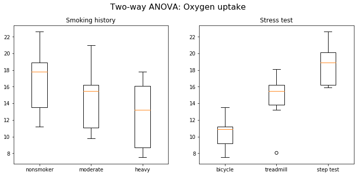

```python
fig, ax = plt.subplots(1, 2, figsize=(12, 5))
fig.suptitle('Two-way ANOVA: Oxygen uptake', size=16, y=1)

# Rows boxplot
x_rows = x.reshape(3, -1).T
ax[0].boxplot(x_rows, labels='nonsmoker moderate heavy'.split())
ax[0].set_title('Smoking history')

# Cols boxplot
x_cols = np.hstack(np.vsplit(x.reshape(-1,3), 3)).T
ax[1].boxplot(x_cols, labels=['bicycle','treadmill','step test'])
ax[1].set_title('Stress test')
```

```python
!jupyter nbconvert stats.ipynb
```

```
[NbConvertApp] Converting notebook stats.ipynb to html
[NbConvertApp] Writing 1288472 bytes to stats.html
```